# R Graphics

### 5.8.2 Horizontal orientation

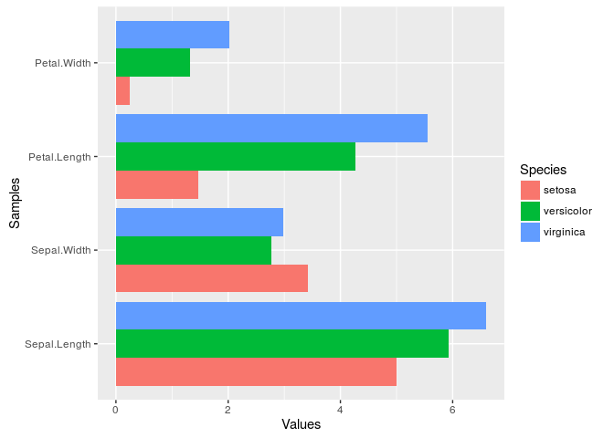

```r
p <- ggplot(df_mean, aes(Samples, Values, fill = Species)) +
            geom_bar(position="dodge", stat="identity") + coord_flip() +
            theme(axis.text.y=element_text(angle=0, hjust=1))
print(p)
```

### 5.8.3 Faceting

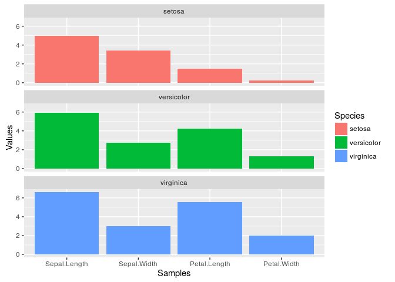

```r
p <- ggplot(df_mean, aes(Samples, Values)) + geom_bar(aes(fill = Species), stat="identity") +
            facet_wrap(~Species, ncol=1)
print(p)
```

### 5.8.4 Error bars

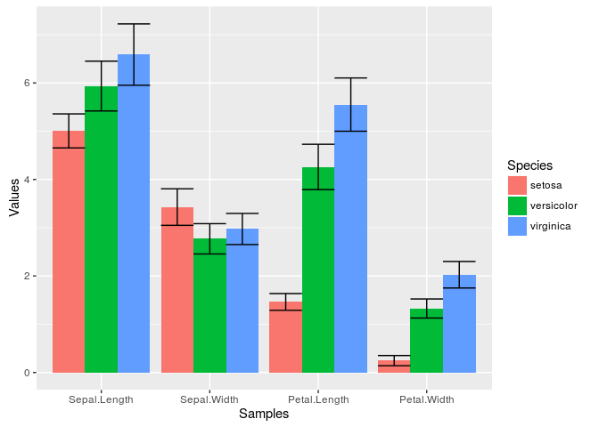

```r
p <- ggplot(df_mean, aes(Samples, Values, fill = Species)) +
        geom_bar(position="dodge", stat="identity") + geom_errorbar(limits, position="dodge")
print(p)
```

### 5.8.5 Mirrored

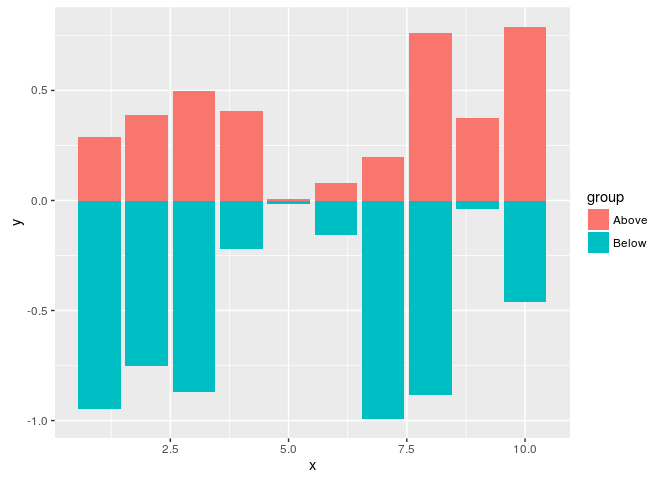

```r
df <- data.frame(group = rep(c("Above", "Below"), each=10), x = rep(1:10, 2), y = c(runif(10, 0, 1), runif(10, -1, 0)))
p <- ggplot(df, aes(x=x, y=y, fill=group)) +
        geom_bar(stat="identity", position="identity")
print(p)
```

## 5.9 Changing Color Settings

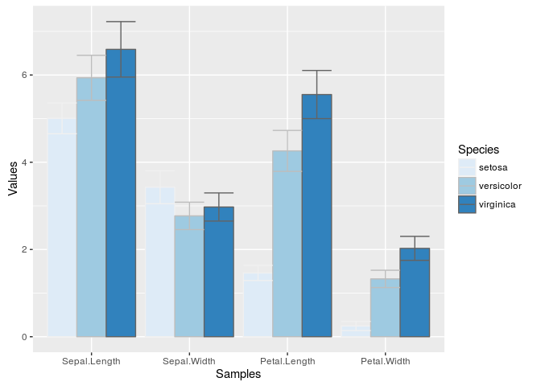

```r
library(RColorBrewer)
# display.brewer.all()
p <- ggplot(df_mean, aes(Samples, Values, fill=Species, color=Species)) +
            geom_bar(position="dodge", stat="identity") + geom_errorbar(limits, position="dodge") +
            scale_fill_brewer(palette="Blues") + scale_color_brewer(palette = "Greys")
print(p)
```

### 5.9.1 Using standard colors

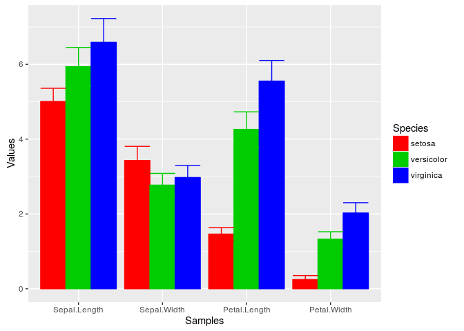

```r
p <- ggplot(df_mean, aes(Samples, Values, fill=Species, color=Species)) +
            geom_bar(position="dodge", stat="identity") + geom_errorbar(limits, position="dodge") +
            scale_fill_manual(values=c("red", "green3", "blue")) +
            scale_color_manual(values=c("red", "green3", "blue"))
print(p)
```

### 5.9.2 Exercise 4

Bar plots

- **Task 1**: Calculate the mean values for the `Species` components of the first four columns in the `iris` data set. Use the `melt` function from the `reshape2` package to bring the data into the expected format for `ggplot`.
- **Task 2**: Generate two bar plots: one with stacked bars and one with horizontally arranged bars.

Structure of iris data set

```r
class(iris)
```

```
## [1] "data.frame"
```

```r
iris[1:4,]
```

```
##   Sepal.Length Sepal.Width Petal.Length Petal.Width Species
## 1          5.1         3.5          1.4         0.2  setosa
## 2          4.9         3.0          1.4         0.2  setosa
## 3          4.7         3.2          1.3         0.2  setosa
## 4          4.6         3.1          1.5         0.2  setosa
```

```r
table(iris$Species)
```

```
##
##     setosa versicolor  virginica
##         50         50         50
```

## 5.10 Data reformatting example

Here for line plot

```r
y <- matrix(rnorm(500), 100, 5, dimnames=list(paste("g", 1:100, sep=""), paste("Sample", 1:5, sep="")))
y <- data.frame(Position=1:length(y[,1]), y)
y[1:4, ] # First rows of input format expected by melt()
```

```
##    Position    Sample1    Sample2    Sample3    Sample4    Sample5
## g1        1 1.32942477 -1.2084007 -0.1958190 -0.4236177  1.7139697
## g2        2 0.92190035 -0.3471160  3.3238031 -1.2340292 -0.3985408
## g3        3 0.01878173  0.8007423 -0.1884464 -0.7419688 -0.5565102
## g4        4 1.95620993  1.7876584 -0.4402745  0.3671016  0.3966960
```

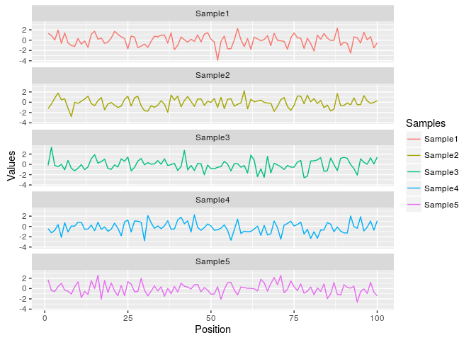

```r
df <- melt(y, id.vars=c("Position"), variable.name = "Samples", value.name="Values")
p <- ggplot(df, aes(Position, Values)) + geom_line(aes(color=Samples)) + facet_wrap(~Samples, ncol=1)
print(p)
```

```r
ggplot(df, aes(Samples, Values, fill=Samples)) + geom_boxplot()
```

[output not shown]

## 5.11 Jitter Plots

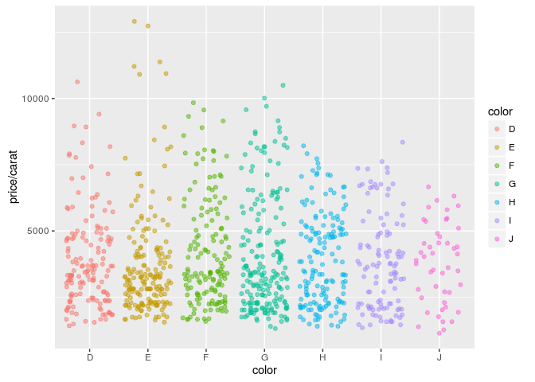

```r
p <- ggplot(dsmall, aes(color, price/carat)) +
            geom_jitter(alpha = I(1 / 2), aes(color=color))
print(p)
```

## 5.12 Box plots

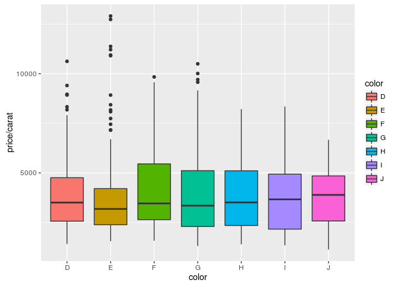

```r
p <- ggplot(dsmall, aes(color, price/carat, fill=color)) + geom_boxplot()
print(p)
```

## 5.13 Density plots

### 5.13.1 Line coloring

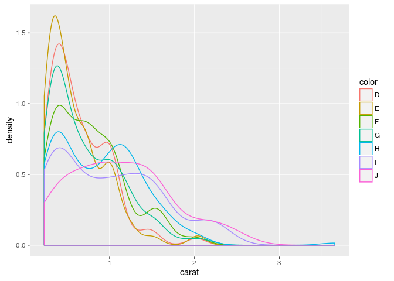

```r
p <- ggplot(dsmall, aes(carat)) + geom_density(aes(color = color))
print(p)
```

### 5.13.2 Area coloring

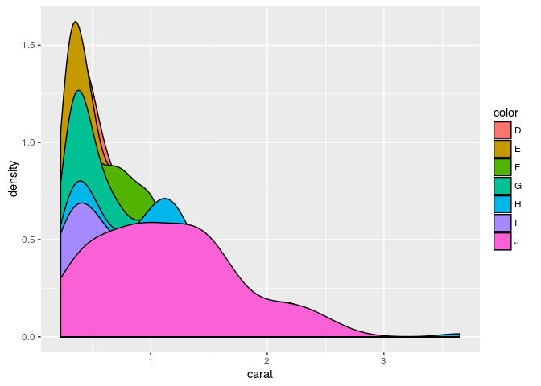

```r
p <- ggplot(dsmall, aes(carat)) + geom_density(aes(fill = color))
print(p)
```

## 5.14 Histograms

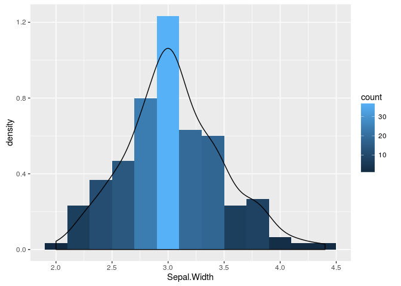

```r
p <- ggplot(iris, aes(x=Sepal.Width)) + geom_histogram(aes(y = ..density..,
            fill = ..count..), binwidth=0.2) + geom_density()
print(p)
```

## 5.15 Pie Chart

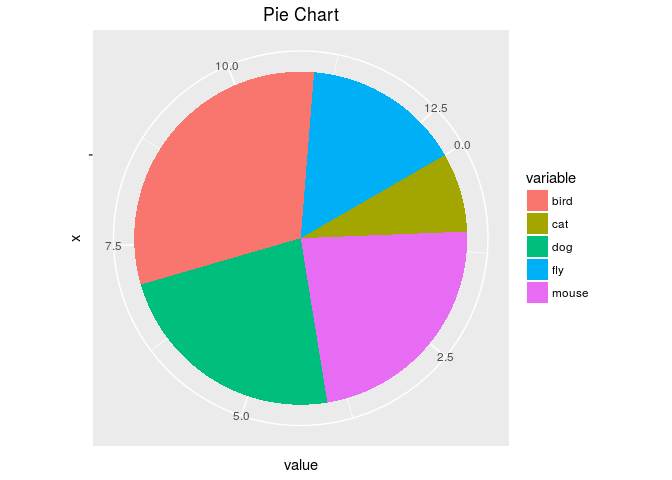

```r
df <- data.frame(variable=rep(c("cat", "mouse", "dog", "bird", "fly")),
                 value=c(1,3,3,4,2))
p <- ggplot(df, aes(x = "", y = value, fill = variable)) +
            geom_bar(width = 1, stat="identity") +
            coord_polar("y", start=pi / 3) + ggtitle("Pie Chart")
print(p)
```

## 5.16 Wind Rose Pie Chart

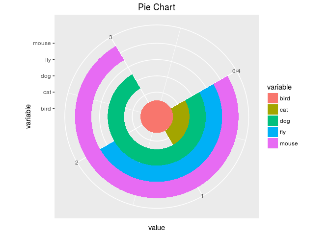

```r
p <- ggplot(df, aes(x = variable, y = value, fill = variable)) +
       geom_bar(width = 1, stat="identity") + coord_polar("y", start=pi / 3) +
       ggtitle("Pie Chart")
print(p)
```

## 5.17 Arranging Graphics on Page

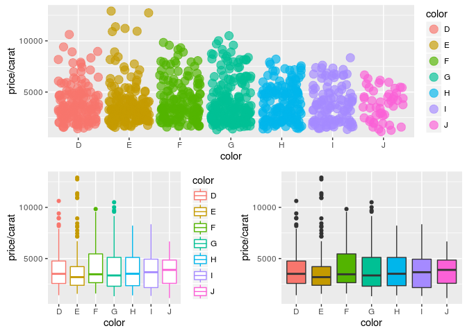

```r
library(grid)
a <- ggplot(dsmall, aes(color, price/carat)) + geom_jitter(size=4, alpha = I(1 / 1.5), aes(color=color))
b <- ggplot(dsmall, aes(color, price/carat, color=color)) + geom_boxplot()
c <- ggplot(dsmall, aes(color, price/carat, fill=color)) + geom_boxplot() + theme(legend.position = "none")
grid.newpage() # Open a new page on grid device
pushViewport(viewport(layout = grid.layout(2, 2))) # Assign to device viewport with 2 by 2 grid layout
print(a, vp = viewport(layout.pos.row = 1, layout.pos.col = 1:2))
print(b, vp = viewport(layout.pos.row = 2, layout.pos.col = 1))
print(c, vp = viewport(layout.pos.row = 2, layout.pos.col = 2, width=0.3, height=0.3, x=0.8, y=0.8))
```

## 5.18 Inserting Graphics into Plots

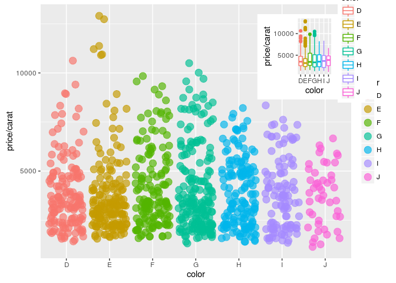

```r
library(grid)
print(a)
print(b, vp=viewport(width=0.3, height=0.3, x=0.8, y=0.8))
```

# 6 Specialty Graphics

## 6.1 Venn Diagrams

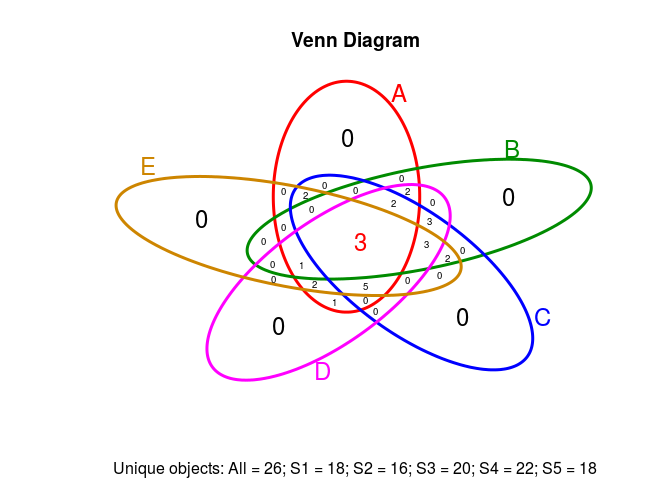

```r
source("http://faculty.ucr.edu/~tgirke/Documents/R_BioCond/My_R_Scripts/overLapper.R")
setlist5 <- list(A=sample(letters, 18), B=sample(letters, 16), C=sample(letters, 20), D=sample(letters, 22), E=sample(letters, 18))
OLlist5 <- overLapper(setlist=setlist5, sep="_", type="vennsets")
counts <- sapply(OLlist5$Venn_List, length)
vennPlot(counts=counts, ccol=c(rep(1,30),2), lcex=1.5, ccex=c(rep(1.5,5), rep(0.6,25),1.5))
```

## 6.2 Compound Structures

Plots depictions of small molecules with `ChemmineR` package

```r
library(ChemmineR)
```

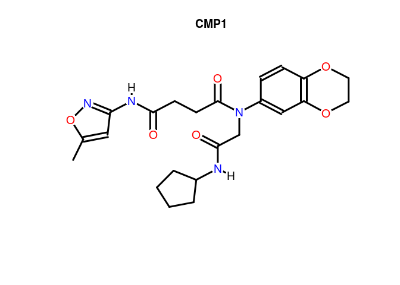

```r
data(sdfsample)
plot(sdfsample[1], print=FALSE)
```

## 6.3 ROC Plots

A variety of libraries are available for plotting receiver operating characteristic (ROC) curves in R:

- [ROCR](http://rocr.bioinf.mpi-sb.mpg.de/)
- [ROC](http://bioconductor.org/packages/release/bioc/html/ROC.html)
- [pROC](http://web.expasy.org/pROC/)
- [ggplot2](http://largedata.blogspot.com/2011/07/plotting-roc-curves-in-ggplot2.html)

## 6.4 Trees

The [`ape`](http://ape-package.ird.fr/ape_screenshots.html) package provides many useful utilities for phylogenetic analysis and tree plotting. Another useful package for plotting trees is [`ggtree`](http://bioconductor.org/packages/release/bioc/html/ggtree.html). The following example plots two trees face to face with links to identical leaf labels.

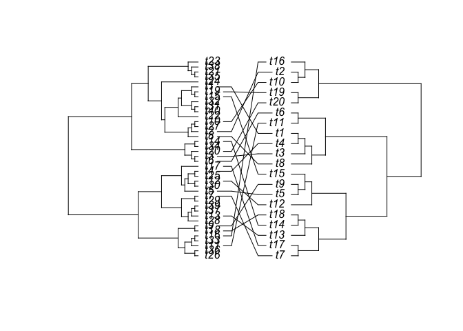

```r
library(ape)
tree1 <- rtree(40)
tree2 <- rtree(20)
association <- cbind(tree2$tip.label, tree2$tip.label)
cophyloplot(tree1, tree2, assoc = association,
            length.line = 4, space = 28, gap = 3)
```

# 7 Genome Graphics

## 7.1 `ggbio`

- What is `ggbio`?
  - A programmable genome browser environment
- Genome broswer concepts
  - A genome browser is a visulalization tool for plotting different types of genomic data in separate tracks along chromosomes.
  - The `ggbio` package (Yin, Cook, and Lawrence 2012) facilitates plotting of complex genome data objects, such as read alignments (SAM/BAM), genomic context/annotation information (gff/txdb), variant calls (VCF/BCF), and more. To easily compare these data sets, it extends the faceting facility of `ggplot2` to genome browser-like tracks.
  - Most of the core object types for handling genomic data with R/Bioconductor are supported: `GRanges`, `GAlignments`, `VCF`, etc. For more details, see Table 1.1 of the `ggbio` vignette [here](http://www.bioconductor.org/packages/release/bioc/vignettes/ggbio/inst/doc/ggbio.pdf).
  - `ggbio`’s convenience plotting function is `autoplot`. For more customizable plots, one can use the generic `ggplot` function.
  - Apart from the standard `ggplot2` plotting components, `ggbio` defines serval new components useful for genomic data visualization. A detailed list is given in Table 1.2 of the vignette [here](http://www.bioconductor.org/packages/release/bioc/vignettes/ggbio/inst/doc/ggbio.pdf).
  - Useful web sites:
    - [ggbio manual](http://www.tengfei.name/ggbio/docs/)
    - [ggbio functions](http://www.tengfei.name/ggbio/docs/man/)
    - [autoplot demo](http://www.tengfei.name/ggbio/docs/man/autoplot-method.html)

### 7.1.1 Tracks: aligning plots along chromosomes

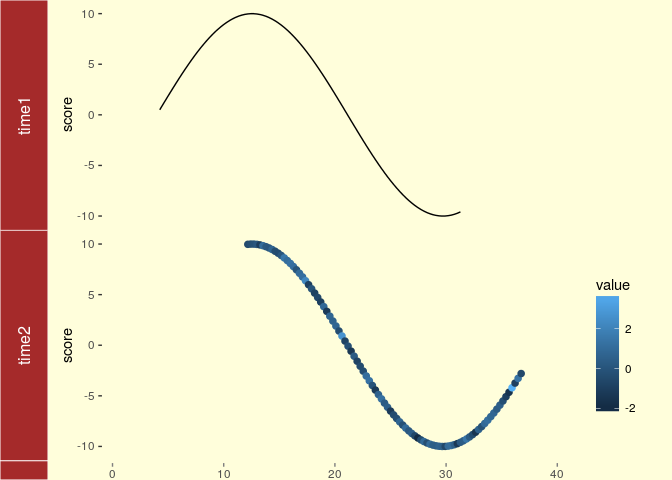

```r
library(ggbio)
df1 <- data.frame(time = 1:100, score = sin((1:100)/20)*10)
p1 <- qplot(data = df1, x = time, y = score, geom = "line")
df2 <- data.frame(time = 30:120, score = sin((30:120)/20)*10, value = rnorm(120-30 +1))
p2 <- ggplot(data = df2, aes(x = time, y = score)) + geom_line() + geom_point(size = 2, aes(color = value))
tracks(time1 = p1, time2 = p2) + xlim(1, 40) + theme_tracks_sunset()
```

### 7.1.2 Plotting genomic ranges

`GRanges` objects are essential for storing alignment or annotation ranges in R/Bioconductor. The following creates a sample `GRanges` object and plots its content.

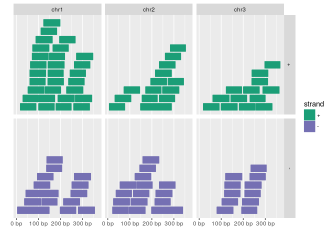

```r
library(GenomicRanges)
set.seed(1); N <- 100; gr <- GRanges(seqnames = sample(c("chr1", "chr2", "chr3"), size = N, replace = TRUE), IRanges(start = sample(1:300, size = N, replace = TRUE), width = sample(70:75, size = N,replace = TRUE)), strand = sample(c("+", "-"), size = N, replace = TRUE), value = rnorm(N, 10, 3), score = rnorm(N, 100, 30), sample = sample(c("Normal", "Tumor"), size = N, replace = TRUE), pair = sample(letters, size = N, replace = TRUE))
autoplot(gr, aes(color = strand, fill = strand), facets = strand ~ seqnames)
```

### 7.1.3 Plotting coverage

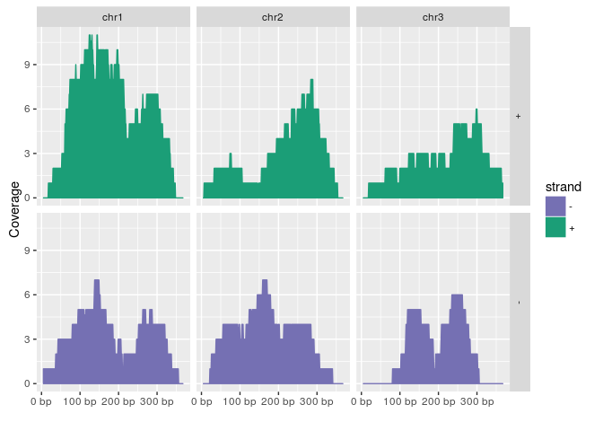

```r
autoplot(gr, aes(color = strand, fill = strand), facets = strand ~ seqnames, stat = "coverage")
```

### 7.1.4 Mirrored coverage

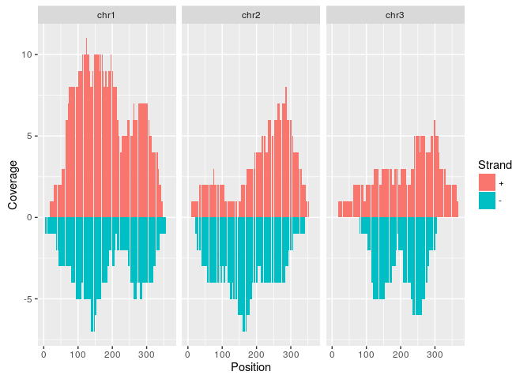

```r
pos <- sapply(coverage(gr[strand(gr)=="+"]), as.numeric)
pos <- data.frame(Chr=rep(names(pos), sapply(pos, length)), Strand=rep("+", length(unlist(pos))), Position=unlist(sapply(pos, function(x) 1:length(x))), Coverage=as.numeric(unlist(pos)))
neg <- sapply(coverage(gr[strand(gr)=="-"]), as.numeric)
neg <- data.frame(Chr=rep(names(neg), sapply(neg, length)), Strand=rep("-", length(unlist(neg))), Position=unlist(sapply(neg, function(x) 1:length(x))), Coverage=-as.numeric(unlist(neg)))
covdf <- rbind(pos, neg)
p <- ggplot(covdf, aes(Position, Coverage, fill=Strand)) +
        geom_bar(stat="identity", position="identity") + facet_wrap(~Chr)
p
```

## 7.2 Circular genome plots

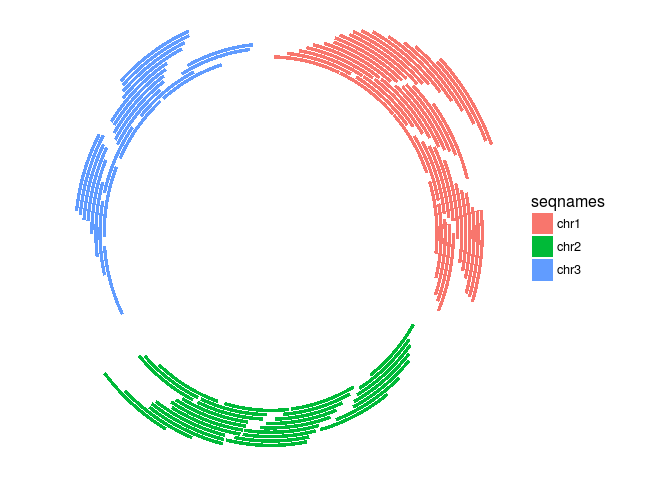

```r
ggplot(gr) + layout_circle(aes(fill = seqnames), geom = "rect")
```

More complex circular example

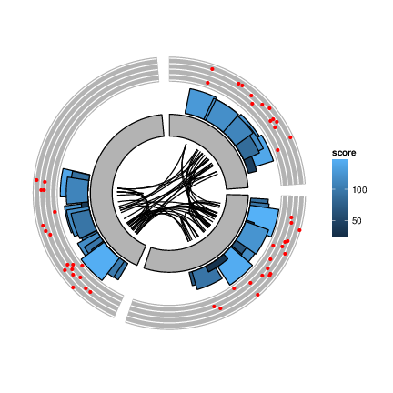

```r
seqlengths(gr) <- c(400, 500, 700)
values(gr)$to.gr <- gr[sample(1:length(gr), size = length(gr))]
idx <- sample(1:length(gr), size = 50)
gr <- gr[idx]
ggplot() + layout_circle(gr, geom = "ideo", fill = "gray70", radius = 7, trackWidth = 3) +
  layout_circle(gr, geom = "bar", radius = 10, trackWidth = 4,
                aes(fill = score, y = score)) +
  layout_circle(gr, geom = "point", color = "red", radius = 14,
                trackWidth = 3, grid = TRUE, aes(y = score)) +
  layout_circle(gr, geom = "link", linked.to = "to.gr", radius = 6, trackWidth = 1)
```

### 7.2.1 Alignments and variants

To make the following example work, please download and unpack this [data archive](http://biocluster.ucr.edu/~tgirke/HTML_Presentations/Manuals/Workshop_Dec_12_16_2013/Rgraphics/data.zip) containing GFF, BAM and VCF sample files.

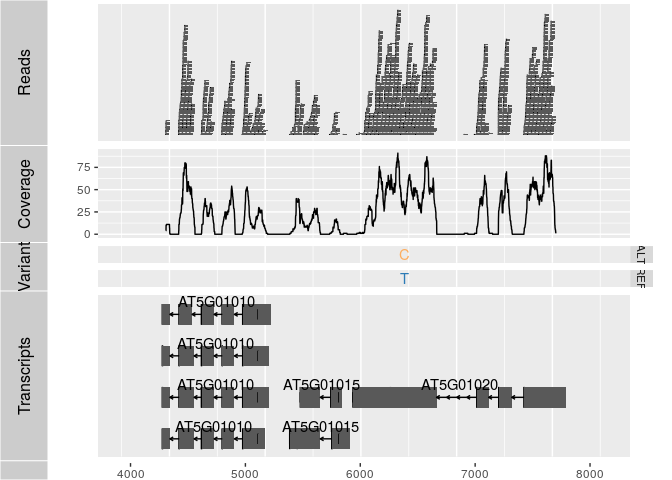

```r
library(rtracklayer); library(GenomicFeatures); library(Rsamtools); library(GenomicAlignments); library(VariantAnnotation)
ga <- readGAlignments("./data/SRR064167.fastq.bam", use.names=TRUE, param=ScanBamParam(which=GRanges("Chr5", IRanges(4000, 8000))))
p1 <- autoplot(ga, geom = "rect")
p2 <- autoplot(ga, geom = "line", stat = "coverage")
vcf <- readVcf(file="data/varianttools_gnsap.vcf", genome="ATH1")
p3 <- autoplot(vcf[seqnames(vcf)=="Chr5"], type = "fixed") + xlim(4000, 8000) + theme(legend.position = "none", axis.text.y = element_blank(), axis.ticks.y=element_blank())
txdb <- makeTxDbFromGFF(file="./data/TAIR10_GFF3_trunc.gff", format="gff3")
p4 <- autoplot(txdb, which=GRanges("Chr5", IRanges(4000, 8000)), names.expr = "gene_id")
tracks(Reads=p1, Coverage=p2, Variant=p3, Transcripts=p4, heights = c(0.3, 0.2, 0.1, 0.35)) + ylab("")
```

## 7.3 Additional examples

See `autoplot` demo [here](http://www.tengfei.name/ggbio/docs/man/autoplot-method.html)

## 7.4 Additional genome graphics

- [`Gviz`](http://www.bioconductor.org/packages/devel/bioc/html/Gviz.html)
- [`RCircos`](http://cran.us.r-project.org/web/packages/RCircos/index.html) (Zhang, Meltzer, and Davis 2013)
- [`Genome Graphs`](http://bioconductor.org/packages/release/bioc/html/GenomeGraphs.html)
- [`genoPlotR`](http://genoplotr.r-forge.r-project.org/)

## 7.5 Genome Browser: IGV

View genome data in IGV

- Download and open [IGV](http://www.broadinstitute.org/igv/download)
- Select in menu in top left corner *A. thaliana* (TAIR10)
- Upload the following indexed/sorted Bam files with `File -> Load from URL...`

```
http://faculty.ucr.edu/~tgirke/HTML_Presentations/Manuals/Workshop_Dec_6_10_2012/Rrnaseq/results/SRR064154.fastq.bam
http://faculty.ucr.edu/~tgirke/HTML_Presentations/Manuals/Workshop_Dec_6_10_2012/Rrnaseq/results/SRR064155.fastq.bam
http://faculty.ucr.edu/~tgirke/HTML_Presentations/Manuals/Workshop_Dec_6_10_2012/Rrnaseq/results/SRR064166.fastq.bam
http://faculty.ucr.edu/~tgirke/HTML_Presentations/Manuals/Workshop_Dec_6_10_2012/Rrnaseq/results/SRR064167.fastq.bam
```

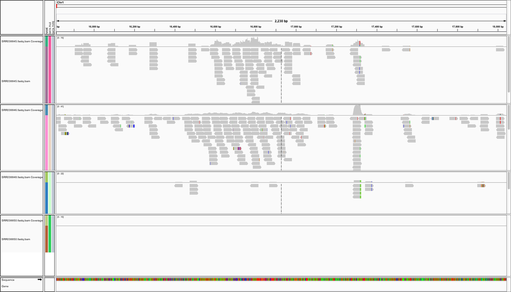

### 7.5.1 Create symbolic links

For viewing BAM files in IGV as part of `systemPipeR` workflows.

- `systemPipeR`: utilities for building NGS analysis [pipelines](https://github.com/tgirke/systemPipeR)

```r
library("systemPipeR")
symLink2bam(sysargs=args, htmldir=c("~/.html/", "somedir/"),
            urlbase="http://myserver.edu/~username/",
            urlfile="IGVurl.txt")
```

### 7.5.2 Controlling IGV from R

Note this may not work on all systems.

```r
library(SRAdb)
startIGV("lm")
sock <- IGVsocket()
session <- IGVsession(files=myurls,
                      sessionFile="session.xml",
                      genome="A. thaliana (TAIR10)")
IGVload(sock, session)
IGVgoto(sock, 'Chr1:45296-47019')
```

# References

Yin, T, D Cook, and M Lawrence. 2012. “Ggbio: An R Package for Extending the Grammar of Graphics for Genomic Data.” *Genome Biol.* 13 (8). doi:10.1186/gb-2012-13-8-r77.

Zhang, H, P Meltzer, and S Davis. 2013. “RCircos: An R Package for Circos 2D Track Plots.” *BMC Bioinformatics* 14: 244–44. doi:10.1186/1471-2105-14-244.